# 05-Layers

Software systems often have a lot of modules, and a common way to organize those modules is in layers where higher layers use functionality provided by lower layers.

In a well-designed system, each layer provides a different level of abstraction (and the higher the layers, the higher the abstraction)

For example, suppose we were designing the operating system of a drone. We may want to divide it into modules like this:

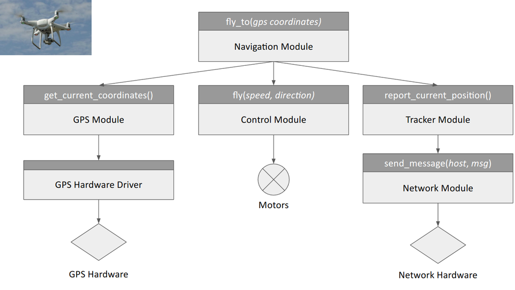

We previously saw that it is good practice to “pull complexity downwards”: keep the interface simple and pull complexity into the implementation.

A similar principle applies when dividing your software into layers: keep the higher layers simple, and pull complexity to the lower layers. We can see this en the above diagram, where the top-most layer provides very high-level functionality, and relies on modules that deal with lower-level functionality.

## Pass-through variables

Sometimes you will have data that has to pass through multiple layers before it is actually used. This is often unavoidable, but it can result in a design with poor information hiding and unnecessary dependencies.

For example, suppose we've implemented a shopping app that has to connect to a server, and where we need to use a specific username when contacting that server. For the sake of argument, let's just say we assign these values to two variables (in practice, we might read them from a configuration file, etc.)

```python
server = "server.example.org"
username = "jrandom"
```

Our code could then involve the following chain of function calls:

```
run_app(server, username, ...)

               |
               V

browse_products(server, username, ...)

               |
               V

purchase(server, username, product, ...)

               |
               V

send_message(server, username, ...)
```

Only the `send_message` function needs to directly use the server and username, but we have to pass that information from the top-most layer (where that information is first obtained) to the bottom-most layer).

Because this data is “global” (shared across modules), you may be tempted to use global variables. Don’t! They almost always result in code that is hard to maintain and debug.

A better solution is to create a *context object* with the information we need to share across layers. Then, we simply pass along that context object that needs access to that shared data.

```python
class AppContext:

    username: str
    server: str

    def __init__(self, username: str, server: str): # Possibly other attributes
        self.server = server
        self.username = username

ctx = AppContext("server.example.org", "jrandom")
```

Now, the function calls look like this:

```
run_app(ctx, ...)

               |
               V

browse_products(ctx, ...)

               |
               V

purchase(ctx, product, ...)

               |
               V

send_message(ctx, ...)
```

Yes, we're still passing a variable through each function but it will always be just one (imagine we had 50 separate pieces of information to pass along)

In OO languages, the context object is often the attribute of many of our classes. For example, in our app we could have classes that look like this:

```python
class DesktopGUI:

    ctx: AppContext
    width: int
    length: int

    def __init__(self, ctx: AppContext, width: int, length: int):
        self.ctx = ctx
        self.width = width
        self.length = length
```

That way, we can easily access the context object from inside that class, without having to add it as a parameter to every method in the class.